# A visual data story of Campus Shopping Habits

## What’s going on with this data?

This project is based on observational data collected near vending machines, campus stores, and convenience stores. I wanted to explore student shopping habits on campus — such as where, when and what students shop, and how busy those places tend to be. The data was collected using a Google Form, and each entry includes a timestamp, the number of items purchased, how long the person stayed, and how many people were around at the time.

By analyzing patterns in time, location, and nearby crowd size, I hope to better understand when and where students prefer to shop on campus, and what behaviors are most common. The main goal is to provide useful insights that might help improve the arrangement and distribution of campus shopping spots like vending machines and campus stores.

## Shopping Time Distribution

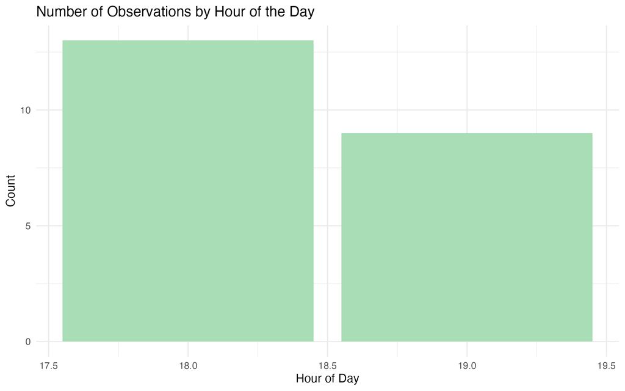

Number of observations by hour of the day

Although I included a timestamp in my form, I didn’t fill it out immediately after each observation. As a result, the time data from the Timestamp column is not reliable for analysis. Instead, I use the answers from my second question, “What time of day was the shopping observed?”, to research shopping patterns over different times of the day.

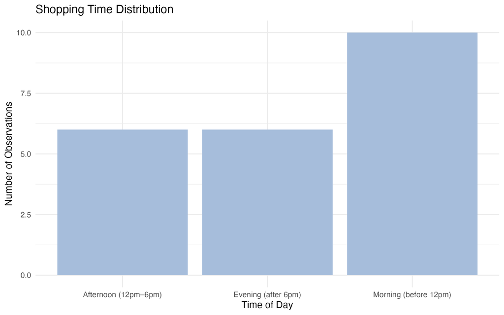

From the chart above, we can see that most shopping activities were observed in the morning (before 12pm). Both afternoon (12pm–6pm) and evening (after 6pm) have the same number of observations, which is fewer than in the morning.

I think this could be because students often need to prepare for breakfast and lunch, or maybe even buy both in the morning. Also, many university classes start in the morning, so students might choose to shop on their way to class or during morning breaks. This trend suggests that morning is a peak period for student shopping on campus.

## People Density by Time of Day

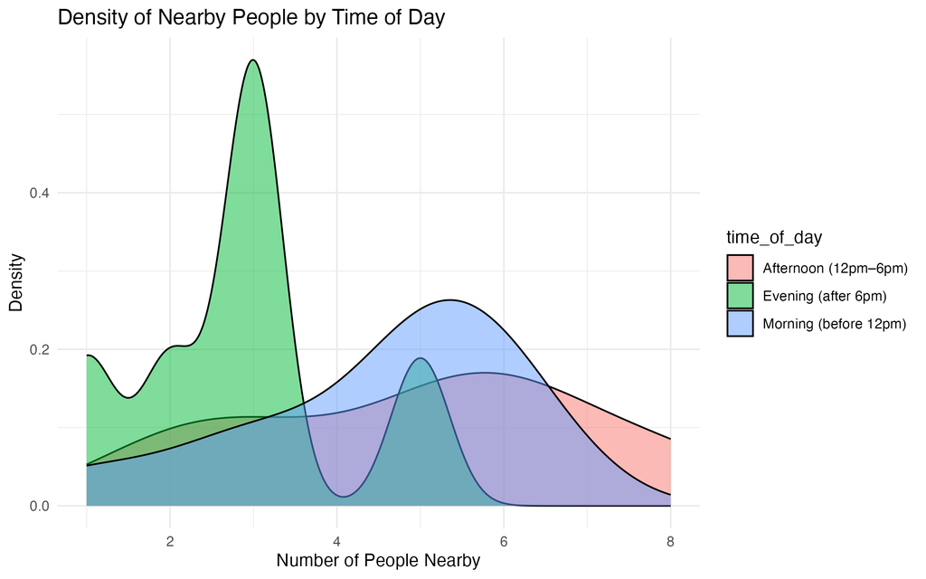

This plot shows the distribution of how many people were nearby when a shopping activity was observed, grouped by time of day. We can see that Evening shopping (green) usually happened when fewer people were around, with a clear peak around 3 people; Morning shopping (blue) had a wider distribution, with many observations occurring when 4–6 people were nearby; Afternoon shopping (red) also showed more crowding, with several observations around 5–6 people. Compared to afternoon, the morning curve has a sharper and clearer peak, while the afternoon curve is smoother and flatter.

This pattern might be because students have different habits at different times of day. In the evening, students may just want to buy something quickly after class, so there are fewer people around. In the morning, many students are getting ready for the day, going to class or buying things before lectures. So, there are usually more people nearby. In the afternoon, students are doing different things — some in class, some free — so the number of people is more spread out, and the curve looks flatter.

## Nearby People Count by Shopping Location

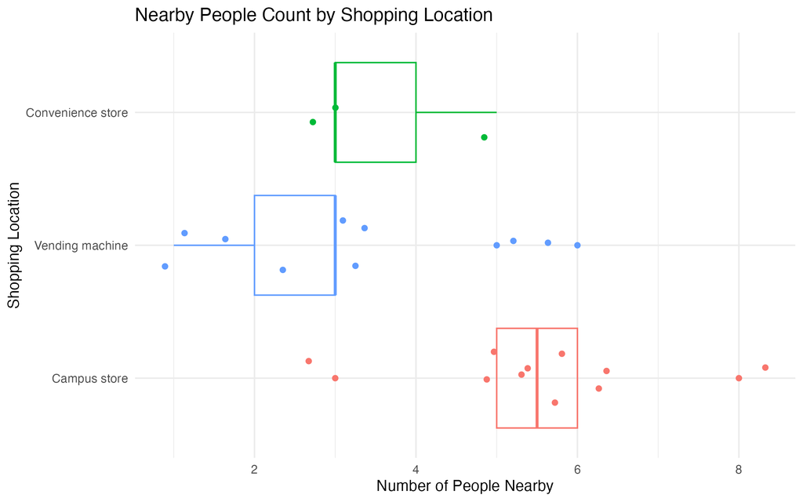

This might suggest that vending machines are more popular when students want to shop quickly and with fewer people, while campus stores tend to attract more group activity or busier times. Convenience stores offer more products than vending machines and have longer opening hours than campus stores, so they may be used throughout the day in different situations.

## Time Spent at Each Location

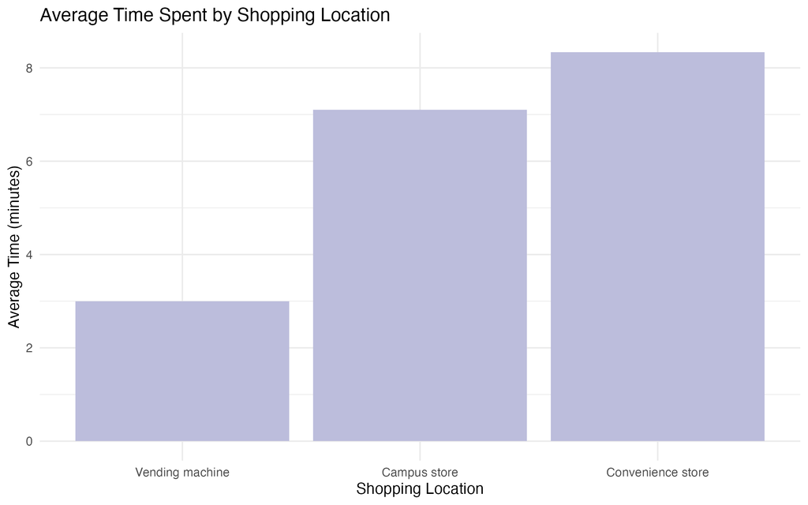

Time Spent at Each Location

This bar chart shows the average time students spent at different campus shopping locations. We can see that students spent the least time at vending machines, a moderate amount of time at campus stores, and the most time at convenience stores.

This may because vending machines are usually used for quick purchases, like grabbing a drink or a snack. In contrast, campus stores and convenience stores offer more items, so people tend to spend more time choosing. Convenience stores offer a wider range of products, but their customers are not only students, so people may spend more time there.

## Conclusion

This observational project gave me some useful opinion on how students shop on campus. I found that mornings are the most common time for shopping, and that different locations attract different levels of activity. Vending machines are quick and quiet, campus stores are busier, and convenience stores are used more flexibly throughout the day.

Even though my dataset is small, it still shows patterns that could help improve the design and management of campus shopping spots. For example, campus stores could be placed near busy classroom buildings, while vending machines could be placed inside those buildings where a lot of people pass by. However, my dataset is very small and limited, so we need to do more research and collect more data to give better and more realistic suggestions.